# Decision Tree - Squid Game style - Episode 4 - Marbles

## Installing required packages

```r
# to install the other packages, run the codes below
 #install.packages("rpart")
 #install.packages("tidyverse")
 #install.packages("rpart.plot")
```

## Loading packages

```r
library("rpart")
library("tidyverse")
```

```r
library("rpart.plot")
```

## Load dataset

```r
data <- read.csv("marbles.csv")
head(data)
```

|  | Age | Occupation | Marital_status | Education_level | Savings_amount | Own_car | Own_house | Monthly_income | Dead_or_Alive |
| --- | --- | --- | --- | --- | --- | --- | --- | --- | --- |
| 1 | 59 | management | married | secondary | 2343 | yes | no | 1042 | Dead |
| 2 | 56 | management | married | secondary | 45 | no | no | 1467 | Dead |
| 3 | 41 | labourer | married | secondary | 1270 | yes | no | 1389 | Dead |
| 4 | 55 | labourer | married | secondary | 2476 | yes | no | 579 | Dead |
| 5 | 54 | management | married | tertiary | 184 | no | no | 673 | Dead |
| 6 | 42 | management | single | tertiary | 0 | yes | yes | 562 | Dead |

```r
glimpse(data)
```

```
## Rows: 11,162
## Columns: 9
## $ Age             <int> 59, 56, 41, 55, 54, 42, 56, 60, 37, 28, 38, 30, 29, 46…
## $ Occupation      <chr> "management", "management", "labourer", "labourer", "m…
## $ Marital_status  <chr> "married", "married", "married", "married", "married",…
## $ Education_level <chr> "secondary", "secondary", "secondary", "secondary", "t…
## $ Savings_amount  <int> 2343, 45, 1270, 2476, 184, 0, 830, 545, 1, 5090, 100, …
## $ Own_car         <chr> "yes", "no", "yes", "yes", "no", "yes", "yes", "yes", …
## $ Own_house       <chr> "no", "no", "no", "no", "no", "yes", "yes", "no", "no"…
## $ Monthly_income  <int> 1042, 1467, 1389, 579, 673, 562, 1201, 1030, 608, 1297…
## $ Dead_or_Alive   <chr> "Dead", "Dead", "Dead", "Dead", "Dead", "Dead", "Dead"…
```

## Shuffle dataset

We want to shuffle the dataset to split the data between a train set and test set.

```r
head(data)
```

|  | Age | Occupation | Marital_status | Education_level | Savings_amount | Own_car | Own_house | Monthly_income | Dead_or_Alive |
| --- | --- | --- | --- | --- | --- | --- | --- | --- | --- |
| 1 | 59 | management | married | secondary | 2343 | yes | no | 1042 | Dead |
| 2 | 56 | management | married | secondary | 45 | no | no | 1467 | Dead |
| 3 | 41 | labourer | married | secondary | 1270 | yes | no | 1389 | Dead |
| 4 | 55 | labourer | married | secondary | 2476 | yes | no | 579 | Dead |
| 5 | 54 | management | married | tertiary | 184 | no | no | 673 | Dead |
| 6 | 42 | management | single | tertiary | 0 | yes | yes | 562 | Dead |

```r
# generate a random list of index
shuffle <- sample(1:nrow(data))
head(shuffle)
```

```
## [1]  940 4703 2433 5967 6528 7825
```

```r
# use index to shuffle the marbles dataset
data <- data[shuffle, ]
head(data)
```

|  | Age | Occupation | Marital_status | Education_level | Savings_amount | Own_car | Own_house | Monthly_income | Dead_or_Alive |
| --- | --- | --- | --- | --- | --- | --- | --- | --- | --- |
| 940 | 35 | unemployed | single | secondary | 127 | yes | no | 162 | Dead |
| 4703 | 30 | management | single | tertiary | 3384 | no | no | 578 | Dead |
| 2433 | 47 | management | single | tertiary | 86 | no | no | 253 | Dead |
| 5967 | 34 | labourer | divorced | secondary | -276 | yes | no | 175 | Alive |
| 6528 | 58 | labourer | married | primary | 65 | no | no | 162 | Alive |
| 7825 | 32 | labourer | single | secondary | 483 | yes | yes | 35 | Alive |

## Create train and test datasets

We will train the model using the train dataset.  
We then test the prediction on the test (unseen) dataset.  
We can split the data 80:20 whereby 80% of data serves to train the model and 20% is used to make predictions.

```r
# create a function to split the dataset into train and test

generate_train_dataset <- function(data, size = 0.8, train = TRUE) {
    n_row = nrow(data)
    total_row = size * n_row
    train_sample <- 1: total_row
    if (train == TRUE) {
        return (data[train_sample, ])
    } else {
        return (data[-train_sample, ])
    }
}
```

Explanation  
- `n_row` counting the number of rows in the dataset  
- `total_row` return the Nth row to generate the train dataset  
- `train_sample` selecting the first row to the Nth rows  
- `if (train ==TRUE){ } else { }` If true, return the train dataset, else return the test dataset

```r
dataset_train <- generate_train_dataset(data, 0.8, train = TRUE)
dataset_test <- generate_train_dataset(data, 0.8, train = FALSE)

# proportion dead in train dataset ~ 47%
prop.table(table(dataset_train$Dead_or_Alive))
```

```
##
##     Alive      Dead
## 0.5286146 0.4713854
```

```r
# proportion dead in train dataset ~ 47%
prop.table(table(dataset_test$Dead_or_Alive))
```

```
##
##     Alive      Dead
## 0.5163457 0.4836543
```

The train dataset has 8929 rows and the test dataset has 2233 rows.

## Generating the model

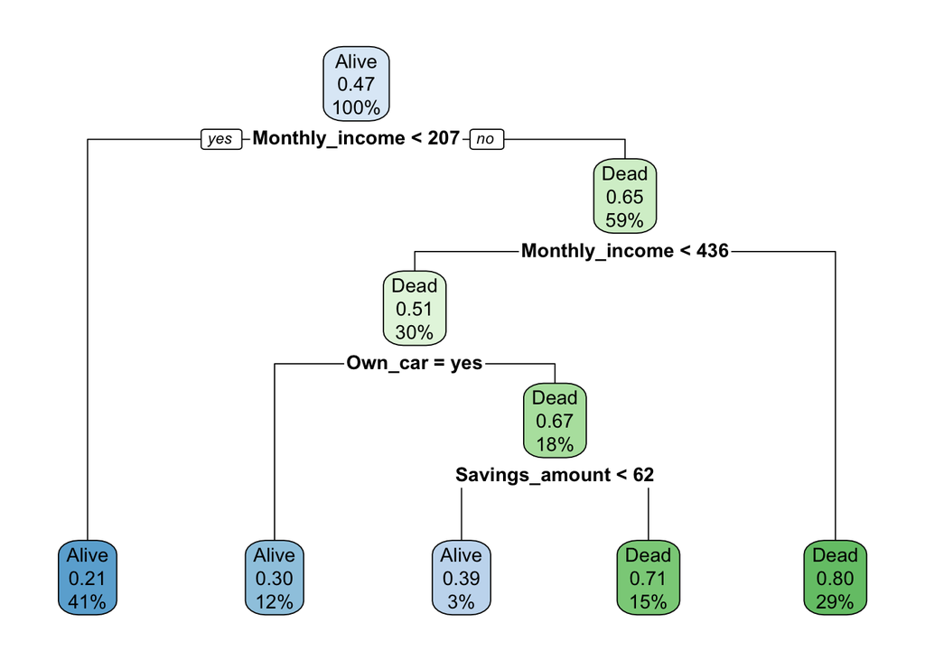

```r
model <- rpart(Dead_or_Alive~., data=dataset_train, method = "class")
rpart.plot(model, extra="auto")
```

## Making a prediction using the test dataset

```r
make_prediction <- predict(model, dataset_test, type="class")

# create table
tab <- table(dataset_test$Dead_or_Alive, make_prediction)
tab
```

```
##        make_prediction
##         Alive Dead
##   Alive   917  236
##   Dead    307  773
```

## Measuring performance

We can use the confusion matrix to evaluate the performance by counting the number of times TRUE instances are classified as FALSE.

```r
accuracy <- sum(diag(tab)) / sum(tab)
print(paste("Accuracy", accuracy))
```

```
## [1] "Accuracy 0.756829377519033"
```

Accuracy is 76% for the test dataset.